# R Notebook

# TODO Things to check

- can we say that csv files have headers if the first line starts with `#`? would greatly simplify the c++ reader
- big cleanup of the various commands we have in main, such as determining some decent order and so on…
- cleanup of the settings options (ideally have them globally and only let the commands decide which ones they want to use so that we do not have millions of commands)

# Preparing the data

> Because the original data from the scala downloader is very limited we have to add extra pieces of data to it. For now, this comes from various places and is a bit of a mess. Should be fixed into something more orderly, but this is my first attempt to document what needs to be done.

## Joining the chunks together

First, the output of the scala downloader chunks should be joined into a single files for commits, projects, paths and file records. During this phase, ids for projects, commits, paths and snapshots are generated and used throughout the rest of the analysis to conserve space.

`scala-join` command

## Downloading Commit histories

The command `download-commit-histories` downloads all commit histories for the existing projects. Currently takes about 8 days to proceed. The output is two files, one (`commit-history-index.csv`) containing the index in the form of:

```
project id, offset in the second file
```

The second file (`commit-history.txt`) contains for each project list of all commits and their parents in the following form: Each project record starts with line `# pid` for debugging purposes, followed by a line for each commit with the following info:

```
commit hash, author time, commit time, parent 1 hash, ... parent n hash -- tag (if any)
```

> Currently these live in `/array/dejavu/data/processed`

## Augmenting Projects

For each project, we want to have extra information available, notably the time the project was created, and number of authors, committers and watchers. For now, we get the information from GHTorrent. So download GHTorrent and then extract only the files we need to save space:

[output not shown]

Then run the `project-extras` command. With default arguments, this creates the augmented projects table of the following schema:

| Column | Description |
| --- | --- |
| 0 | Project id |
| 1 | User name |
| 2 | Repo name |
| 3 | Fork id (-1 for not a fork, -2 for fork of unknown project) |
| 4 | Created at (UNIX timestamp) |
| 5 | # of Committers |
| 6 | # of Authors |
| 7 | # of Watchers |

> The data from GHTorrent are not the best, TBH. Should be replaced with data obtained via the Github API (approx 10 days)

Here’s the output of what I have ran (with my comments what respective numbers mean)

```
peta@prl1e:~/devel/dejavuii/build$ ./dejavu project-extras
OH HAI!
CAN I HAZ STUFFZ?
I CAN HAZ project-extras NAO:
Importing from file /data/dejavuii/data/processed/projects.csv
Total number of projects 2405680
Creating projects map based on project names...
Analyzing GH torrent projects...
Total projects:    110719632 # total number of GHTorrent projects
Language projects: 11632118  # JS projects in GhTorrent
Missing projects:  9291783   # projects on GhT that are not in our database
Missing forks:     7760942   # how many of the above are forks (our dataset should not contain forks)
Missing deleted:   302869    # how many of them are deleted (our dataset should not contain deleted projects)
Projects:          2405680   # total number of our projects
Unaccounted:       121075    # our projects that are not in GhTorrent -- interesting
Forks:             26        # our projects which are forks of something that is not in our database
Missing forks:     6         # projects reported as forks on GhTorrent that are in our dataset - should be verified !!
Commits analyzed:  66130615  # number of commits from GH torrent relevant to our projects, not important
Commits skipped:   209953    # number of commits in ghtorrent for which no project id was available, why??? forks?
Affected projects: 2067435   # number of projects from our corpus for which the committers and authors numbers were calculated
Rows used:         23602206  # not important, number of rows in watchers.csv used
Affected projects: 600568    # number of projects that have watchers - this is interestingly high
KTHXBYE!

real    62m4.128s :(
user    22m3.283s
sys     3m18.078s
```

```r
projects = read.csv("/data/dejavuii/data/filtered/projects.csv")
```

```r
summary(projects$committers)
```

```
   Min. 1st Qu.  Median    Mean 3rd Qu.    Max.
  0.000   1.000   1.000   1.441   2.000 654.000
```

```r
summary(projects$authors)
```

```
    Min.  1st Qu.   Median     Mean  3rd Qu.     Max.
   0.000    1.000    1.000    1.385    1.000 2252.000
```

```r
summary(projects$watchers)
```

```
     Min.   1st Qu.    Median      Mean   3rd Qu.      Max.
     0.00      0.00      0.00      9.78      0.00 229759.00
```

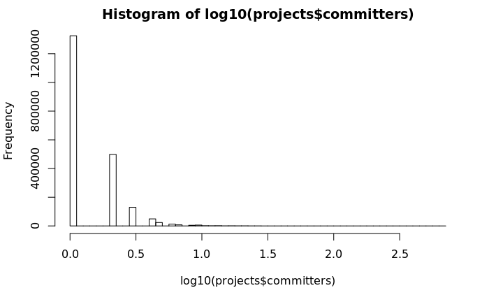

```r
hist(log10(projects$committers), breaks = 100)
```

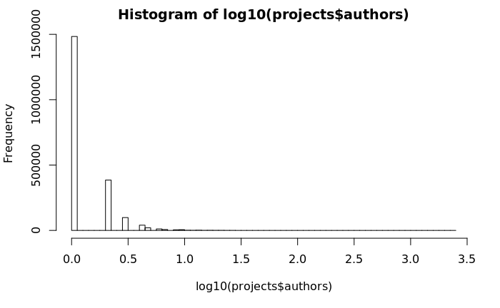

```r
hist(log10(projects$authors), breaks = 100)
```

## Detecting commit originals

First we must augment each commit with its original project. If commit appears in a single project alone, that project is its original, for commits appearing in multiple projects, the oldest such project is the original. To do this, run the `commit-originals`. It is a bit trickier since it requires that projects have already been updated with the `project-extras` step, but takes the original `commits.csv` and `files.csv`:

```
peta@prl1e:~/devel/dejavuii/build$ time ./dejavu commit-originals
OH HAI!
CAN I HAZ STUFFZ?
I CAN HAZ commit-originals NAO:
Importing from file /data/dejavuii/data/filtered/projects.csv
Total number of projects 2405680
Importing from file /data/dejavuii/data/processed/commits.csv
Total number of commits 42383751
Analyzed rows: 1796203304
Analyzed project-commit pairs: 62518504
KTHXBYE!

real    17m47.191s
user    15m0.738s
sys     2m46.316s
```

```r
commits = read.csv("/data/dejavuii/data/filtered/commits.csv")
```

```r
summary(commits)
```

```
       id                                                 hash               time            numProjects       originalProjectId
 Min.   :       0   0000002a080d3f7ea40362415f1cedd9425892c7:       1   Min.   :0.000e+00   Min.   :   1.000   Min.   :      0
 1st Qu.:10595938   0000007c6ff6e5b876cb4af728e32103c1854d9a:       1   1st Qu.:1.402e+09   1st Qu.:   1.000   1st Qu.: 137646
 Median :21191875   000000881126391a2e92db6076cb3ed3e90918ad:       1   Median :1.443e+09   Median :   1.000   Median : 317534
 Mean   :21191875   00000100d3d568a8e280df0fd9097c81bfac3b48:       1   Mean   :3.919e+12   Mean   :   1.475   Mean   : 506478
 3rd Qu.:31787812   000002790dcd909def5778f85272c283ca967b57:       1   3rd Qu.:1.481e+09   3rd Qu.:   1.000   3rd Qu.: 719645
 Max.   :42383750   000002f1f74d2717913b768e861e2e68509ef958:       1   Max.   :1.845e+19   Max.   :3986.000   Max.   :2405679
                    (Other)                                 :42383745
```

Whoa… There is a commit that is in almost 4k projects:) - and we *do not* have explicit forks in the dataset.

```r
length(commits$time[commits$time == 0])
```

```
[1] 135
```

Also we have 135 commits with time being equal to 0. This is slightly annouing, unless the commits really were from 1970:)

> TODO check this!!!!

```r
hist(log10(commits$numProjects), breaks = 100)
```

[output not shown]

## Detecting snapshot originals

For this, we use the `snapshot-originals` command. This takes the commits from previous step and snapshots and then determines for each snapshot things like its original commit, number of occurences and so on.

```
OH HAI!
CAN I HAZ STUFFZ?
I CAN HAZ snapshot-originals NAO:
Importing from file /data/dejavuii/data/processed/fileHashes.csv
Total number of snapshots 99300992
Importing from file /data/dejavuii/data/filtered/commits.csv
Total number of commits 42383751
Rows:                   1796203304
Identical commit times: 1800262
Snapshots analyzed:     99300991
Unique snapshots:   67600837
Original snapshots: 31700154
Copies snapshots:   1140860388
KTHXBYE!

real    77m11.128s
user    72m11.588s
sys     4m59.250s
```

> For now, it takes a lot of time, but that is kind of expected since it walks over all file records.

```r
snapshots = read.csv("/data/dejavuii/data/filtered/snapshots.csv")
```

```r
summary(snapshots$occurences)
```

[output not shown]

## Determining interesting projects

An interresting project is a project that has at least one of the following:

- has at least one watcher
- has created at least one original snapshot
- has created at least one unique snapshot
- has at least one original commit (i.e. commit somewhere else as well, i.e. has implicit or explicit forks)
- has a sequence of at least 20 consecutive commits for a period of over 3 months where no two adjacent commits are separated by more than 30 days

> TODO perhaps also any project that has been forked at least once?

The criteria above should provide us with an overapproximation, i.e. some of the selected projects are likely to be pretty boring, but we should not skip any interesting project.

```
peta@prl1e:~/devel/dejavuii/build$ time ./dejavu interesting-projects
OH HAI!
CAN I HAZ STUFFZ?
I CAN HAZ interesting-projects NAO:
Importing from file /data/dejavuii/data/filtered/commits.csv
Total number of commits 42383751
Importing from file /data/dejavuii/data/filtered/projects.csv
Total number of projects 2405680
Importing from file /data/dejavuii/data/filtered/snapshots.csv
Total number of snapshots 99300991
Summarizing project information...
Summarizing commit information...
Summarizing snapshot information...
Analyzing file records...
Analyzed 1796203304 file records
Calculating spans...
 Writing results...
KTHXBYE!

real    38m18.928s
user    35m11.200s
sys     3m7.548s
```

```r
projects = read.csv("/data/dejavuii/data/filtered/projects-interesting.csv")
```

Now that we have the data, let’s look at some definitions of interesting projects.

```r
length(projects$watchers[projects$watchers > 0])
```

```
[1] 600568
```

Ok, actually quite a lot of projects have at least one watcher, though this comes from GhTorrent so take it with a grain of salt.

Let’s add some columns to projects so that we know the project duration and span duration:

```r
# in days
projects$duration = (projects$lastCommit - projects$firstCommit) / 3600 / 24
projects$spanDuration = (projects$spanEnd - projects$spanStart) / 3600 / 24
```

And get summaries for some overview:

```r
summary(projects)
```

```
       id             watchers            changes            snapshots        uniqueSnapshots    originalSnapshots     commits         uniqueCommits      originalCommits       paths            spanStart
 Min.   :      0   Min.   :     0.00   Min.   :        1   Min.   :     1.0   Min.   :     0.0   Min.   :    0.00   Min.   :    1.00   Min.   :    0.00   Min.   :    0.0   Min.   :     1.0   Min.   :0.000e+00
 1st Qu.: 601420   1st Qu.:     0.00   1st Qu.:        6   1st Qu.:     5.0   1st Qu.:     1.0   1st Qu.:    0.00   1st Qu.:    1.00   1st Qu.:    1.00   1st Qu.:    0.0   1st Qu.:     3.0   1st Qu.:1.409e+09
 Median :1202840   Median :     0.00   Median :       19   Median :    17.0   Median :     5.0   Median :    0.00   Median :    4.00   Median :    3.00   Median :    0.0   Median :     9.0   Median :1.443e+09
 Mean   :1202840   Mean   :     9.78   Mean   :      747   Mean   :   205.8   Mean   :    28.1   Mean   :   13.18   Mean   :   25.99   Mean   :   15.12   Mean   :    2.5   Mean   :   268.7   Mean   :1.534e+13
 3rd Qu.:1804259   3rd Qu.:     0.00   3rd Qu.:       79   3rd Qu.:    61.0   3rd Qu.:    17.0   3rd Qu.:    2.00   3rd Qu.:   13.00   3rd Qu.:   10.00   3rd Qu.:    0.0   3rd Qu.:    33.0   3rd Qu.:1.477e+09
 Max.   :2405679   Max.   :229759.00   Max.   :138586823   Max.   :203504.0   Max.   :124723.0   Max.   :83805.00   Max.   :74002.00   Max.   :34650.00   Max.   :52067.0   Max.   :362091.0   Max.   :1.845e+19
    spanEnd           spanCommits          numSpans       firstCommit          lastCommit           duration          spanDuration
 Min.   :0.000e+00   Min.   :    1.00   Min.   : 1.000   Min.   :0.000e+00   Min.   :0.000e+00   Min.   :0.000e+00   Min.   :   0.000
 1st Qu.:1.411e+09   1st Qu.:    1.00   1st Qu.: 1.000   1st Qu.:1.406e+09   1st Qu.:1.416e+09   1st Qu.:0.000e+00   1st Qu.:   0.000
 Median :1.444e+09   Median :    3.00   Median : 1.000   Median :1.440e+09   Median :1.448e+09   Median :4.000e+00   Median :   1.501
 Mean   :1.534e+13   Mean   :   21.34   Mean   : 1.657   Mean   :7.669e+12   Mean   :2.301e+13   Mean   :1.775e+08   Mean   :  18.760
 3rd Qu.:1.480e+09   3rd Qu.:   10.00   3rd Qu.: 2.000   3rd Qu.:1.475e+09   3rd Qu.:1.485e+09   3rd Qu.:6.900e+01   3rd Qu.:  15.912
 Max.   :1.845e+19   Max.   :74002.00   Max.   :55.000   Max.   :1.845e+19   Max.   :1.845e+19   Max.   :2.135e+14   Max.   :4557.814
```

OK, this looks reasonable to be on the first glance. The duration gets super super big a few times, but that is most likely because of a few commits having time of 0 in the original dataset. The median and 3rd quartile look decent.

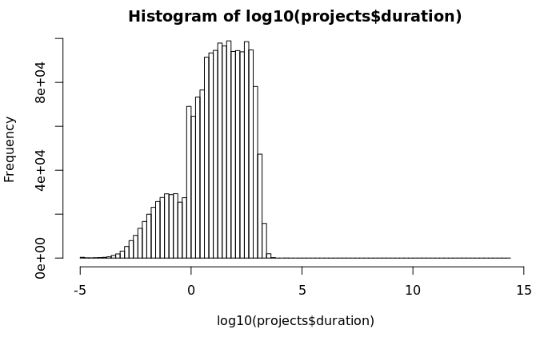

```r
hist(log10(projects$duration), breaks = 100)
```

Yeah… Note its in days…

```r
sum(projects$duration > 365 & projects$commits >= 20)
```

```
[1] 148126
```

Let’s see if we add projects with any original content to this lot:

```r
sum((projects$duration > 365 & projects$commits >= 20) | projects$originalCommits > 0 | projects$originalSnapshots > 0)
```

```
[1] 972698
```

Hm… this is much more projects than I would have guessed. Let’s add to it also projects that contain unique contents:

```r
sum((projects$duration > 365 & projects$commits >= 20) | projects$originalCommits > 0 | projects$originalSnapshots > 0 | projects$uniqueCommits > 0 | projects$uniqueSnapshots > 0)
```

```
[1] 2359665
```

That’s almost all projects…

Different way: How many projects we need if we want to see all original commits:

```r
sum(projects$originalCommits > 0)
```

```
[1] 154120
```

If we add files to it, it grows back to the 900k projects. This is expected - commits should be only rarely shared:

```r
sum(projects$originalCommits > 0 | projects$originalSnapshots > 0)
```

```
[1] 943136
```

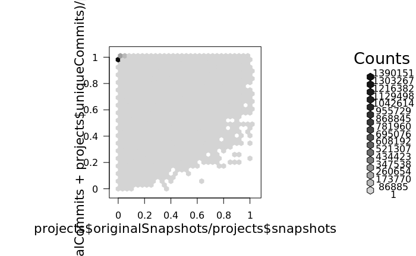

```r
library(hexbin)
plot(hexbin(x = projects$originalSnapshots / projects$snapshots, y = (projects$originalCommits + projects$uniqueCommits) / projects$commits))
```